# Linear Regression - Predicting Individual Medical Costs Billed by Health Insurance

4/18/2020

Victor Uduma

## Author: Victor Uduma

## Program:Homework_3.rmd

## Purpose: perform linear regressions models on the insurance dataset ## ##

## Date Created: 05/04/2020

## Exploratory Data Analysis

in this assignment we are exploring the insurance dataset, which has 1338 observations and 7 categories. in the dataset, %50.52 of the observations are male, and %27.20 of the observations come from the southeast reigion of the united states. 79.52 percent of the observations do not smoke and 42.90 percent of observations have no children on their insurance. The average age for the observations is 39.2 with the standard deviation being 14.04, the average BMI is 30.67 and the standard deviation for BMI is 6.1. The average amount for charges is 13270 dollars and the standard deviation is 12110.01 dollars.

## Data Visualization

for the data visualization, I created 6 figures, figures 1-4 consist of boxplots and 5-6 are scatterplots.

for figure 2 we checked the medical costs for people who smoke and don’t smoke. people who smoked had a higher medical cost average than those who didn’t, although non smokers have more outliers compared to smokers.

in figure 4 we have medical costs based on sex, with the average medical costs being the same between them, although women tended to have more outliers compared to men.

for figure 5, we checked to see if there was a correlation between medical costs and the age of particpants using a scatterplot.what we found was that there is a small positive linear correlation between the age of the participants and the medical costs.

for figure 6 we checked the correlation between medical costs and body mass index using scatterplot as well. we were able to figure that there is a small positive linear correlation between body mass index and medical costs.

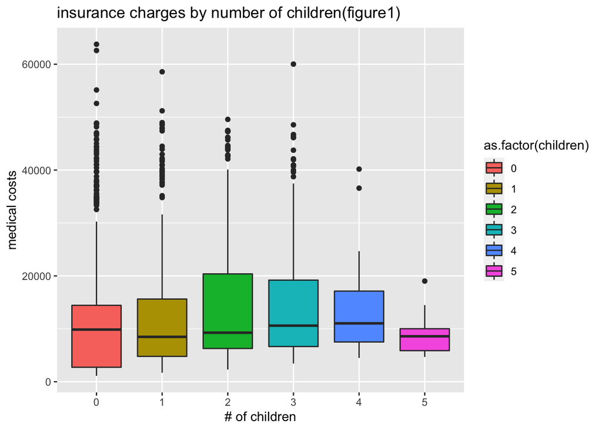

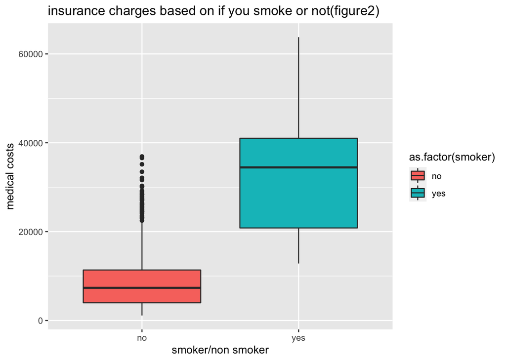

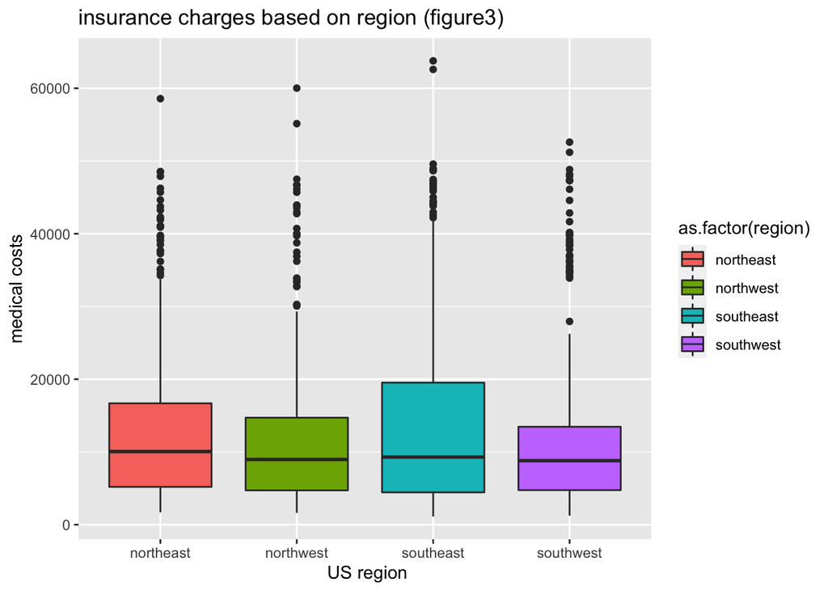

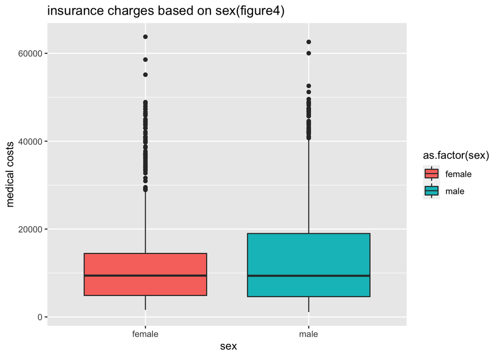

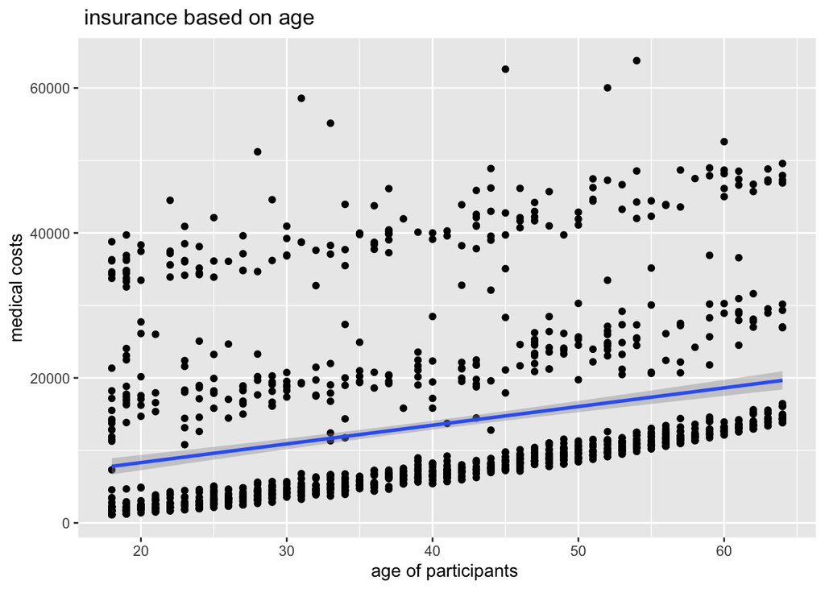

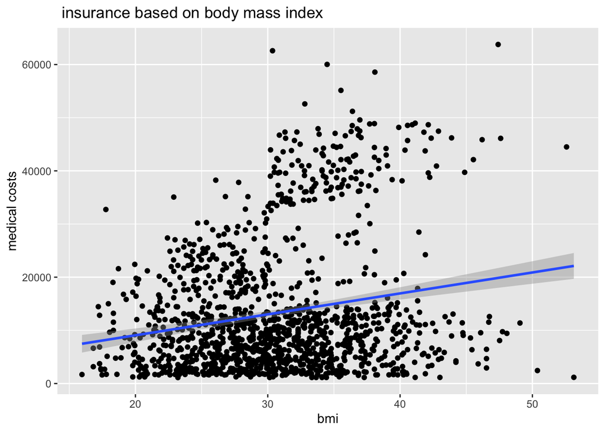

## Multiple Linear Regression Results

for the multiple linear regression, I decided to make the charges our outcome variable and the rest of our variables perdictors. after creating our multiple linear regression, we were able to find the intercept coeffcient to be -11927.17 which means that when all the perdictor varibles are equal to zero, the medical cost charged to an individual is $-11927.17. holding all other independent variables constant.

for the age perdictor, i was able to able to determine that for every 1 year increase in the age of an individual, the medical cost billed by health insurance increases by 257.19 dollars, holding all other independent variales constant.

for the BMI perdictor, I determined that for every 1 unit increase in BMI, the medical costs that are billed by health insurances increases 336.91 dollars. holding all other independent varibles equal.

for the sex perdictor, the medical costs billed by health insurance is 128.16 dollars lower for men than it is for women, holding all other independent variables constant

for the smoker perdictor, the medical costs billed by health insurance is 23836.41 dollars higher for people who do smoke than it is for people who don’t smoke, holding all independent variables equal constant.

for the northwest region, the medical costs billed by health insurance is 380.04 dollars lower for people living in the northwest region of the United States than it is for people livinf in the northeast region of the united states, holding all other independent variables constant.

in the southeast region, the medical costs billed by health insurance is 1033.14 dollars lower for people living in the southeast region than it is for people living in the northeast region, holding all other independent variables constant

in the southwest region, the medical costs billed by health insurance is 952.89 lower for people living in the southwest region than it is for people living in the north east region, holding all other independent variables constant

## Linear Regression Assumptions

we then check whether or not the assumptions for the linear test are violated or not, we do this by running a plot function that would provide four different plots that check to see if any assumptions were violated. based on the third plot, we can see that the homoscedasticity was violated, as the red line is not horizontal and flat and the data points are not evenly spread out on each side.

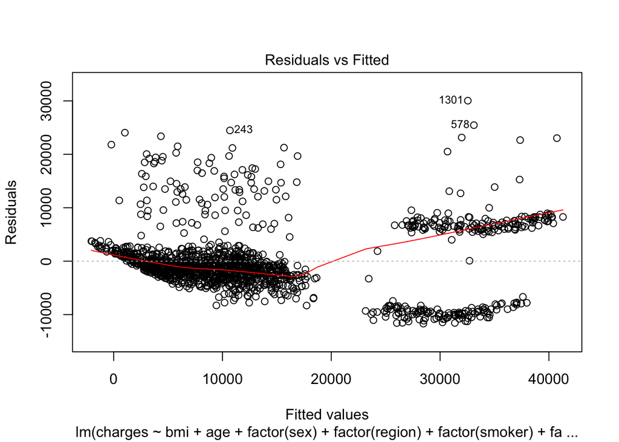

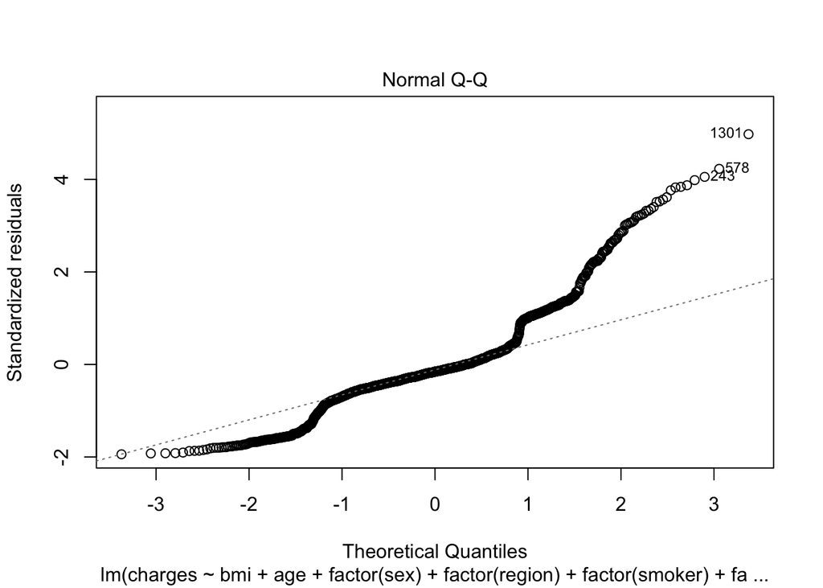

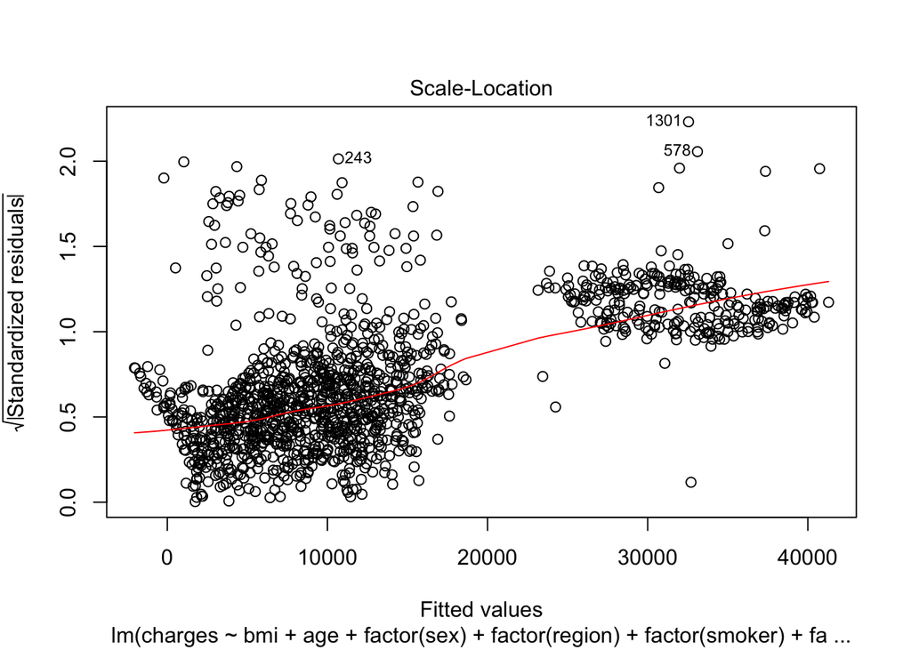

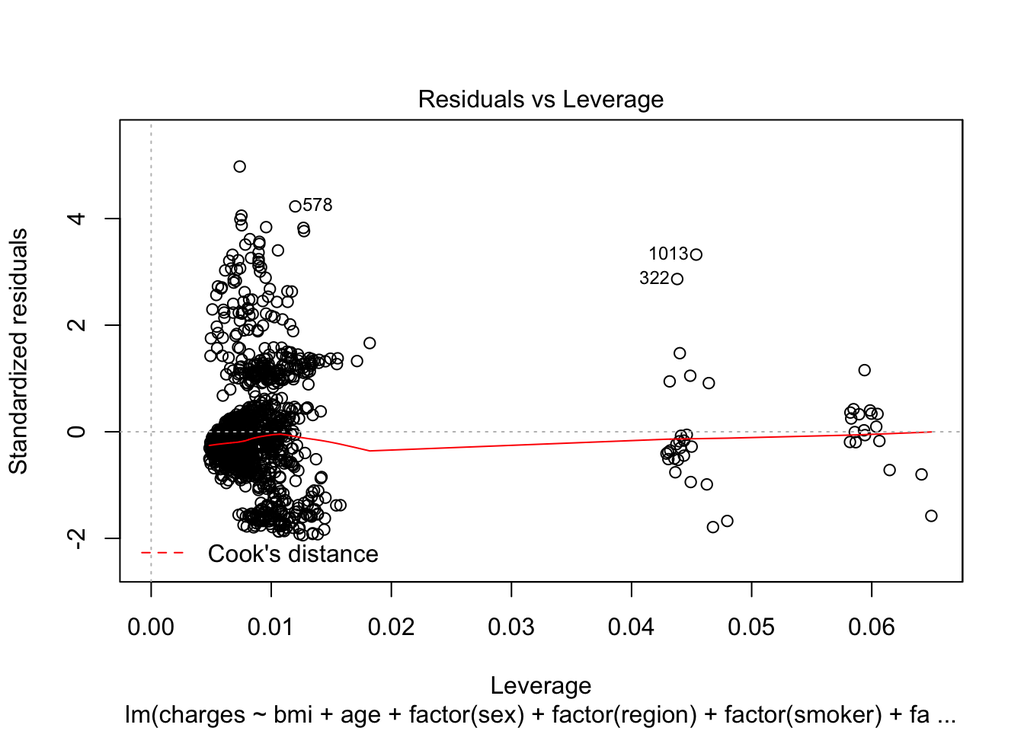